# SEMANTIC HASHING

Fast retrieval methods often rely on intersecting sets of documents that contain a particular word or feature. Semantic hashing is no exception. Each of the binary values in the code assigned to a document represents a set containing about half the entire document collection. Intersecting such sets would be slow if they were represented by explicit lists, but all computers come with a special piece of hardware – the address bus – that can intersect sets in a single machine instruction. Semantic hashing is simply a way of mapping the set intersections required for document retrieval directly onto the available hardware.

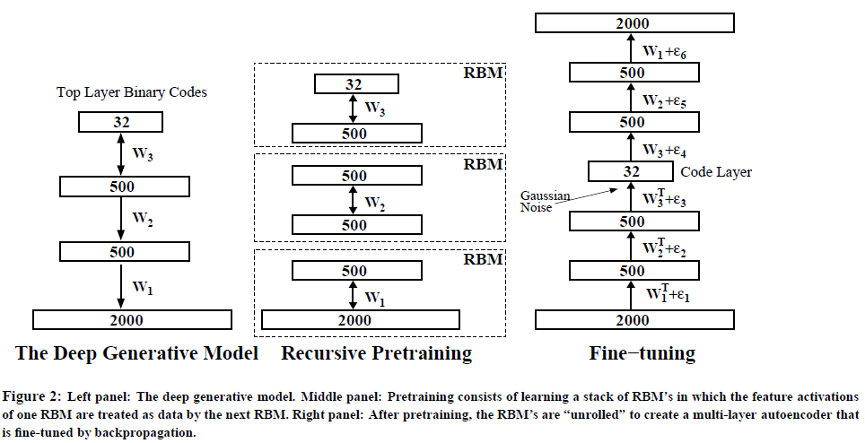

## Krizhevsky discover later that its easier to just use binary stochastic unit in the code layer during training. So during the forward pass we stochastically pick a binary value using the output of logistic and during the backward pass we pretend that we transmitted the real value of probability from the logistic and that give the smooth gradient for back propagation.

## Once we got these short binary code we could do a sequential search where for each known document we store a code and then when the query document arrives we first extract its code if its not one of our name documents and then compare the code with the codes of stored document. The comparing is very fast, parallel processing is use, but still its kind of slow, for billion data.

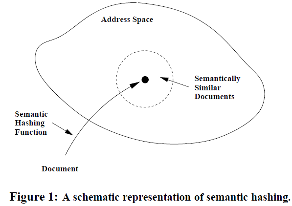

## One faster thing is possible, we can treat the code as if it was a memory address .

## So the idea is we take the document and we use the deep autoencoder as a hash function that converts a documents into 32 bit address, now we have memory with 32 bit address and in that memory each address have a pointer back to the docs that have that address.

## If several documents have the same address we can make a little list there, if the autoencoder is successful in making similar documents with similar address , then it will be the fast way of finding similar documents you simply take the query docs and go to the address in memory that corrresponds to its binary code and then you will look near by addresses, in other words you start flipping bits in that address to access nearby addresess and we will imagine a hamming ball fo nearby addresses that differ by just a few bytes, what we expected to find in nearby addresses is sematically similar docs.

## NOTE:- Here we have 32 bits or 32 dimension space, its huge more complex space, but same time we have lot of points nearby with sematically similar